# Proyecto Series Temporales

Jose Luis Ruiz Casado

2020-12-23

# Análisis de una serie temporal de fabricación de una serie temporal

Vamos a analizar el dataset proporcionado sobre la fabricación de un producto eléctrico. En primer lugar leemos el dataset del fichero con extensión xlsx.

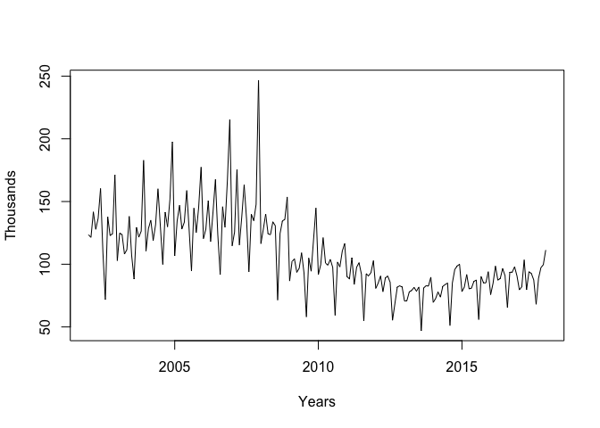

```r
datos <- read_xlsx("Datos.xlsx")
timeSerie.ts <-  ts(datos$CANT, start = c(2002, 1), frequency = 12)
plot.ts(timeSerie.ts, ylab = "Thousands", xlab = "Years")
```

Esta es la gráfica para la serie temportal, también podemos hacer una gráfica para la serie temporal de cada año.

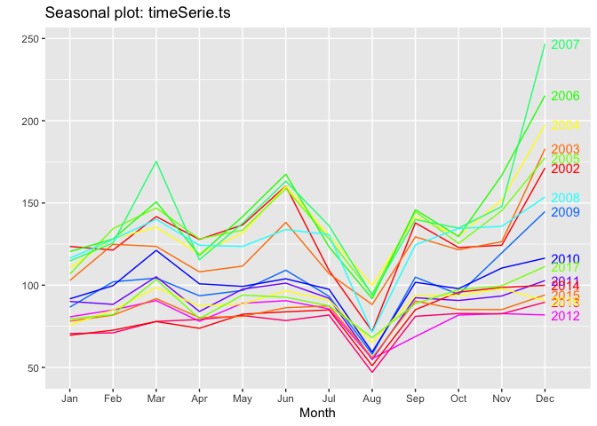

En esta gráfica se muestra la serie temporal de cada durante los distintos meses.

## Descomponiendo la serie temporal

Podemos descomponer la serie temporal separándola en sus componentes: tendencia, ciclos, irregularidad, componente estacional y remanente. En concreto se aplicará la descomposición additiva:

$y_t = S_t + T_t + R_t$

Al observar la gráfica Seasonal plot podemos observar que parece que la serie sigue un patrón a lo largo de los meses, lo que puede indicar que la seria sea *estacional*.  
Una serie temporal estacional se compone de un componente tendencia, un componente estacional y un componente aleatorio. Podemos decomponerla con la función *decompose* de R.

```r
timeSerie.comp <- decompose(timeSerie.ts)
```

Esto nos permite extraer los componentes estimados de la serie temporal.

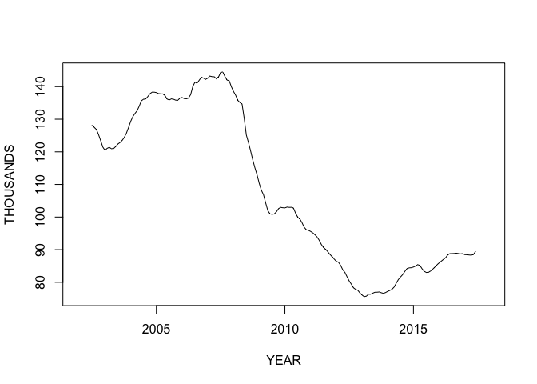

Este es el componente de la tendencia estimada. En esta tendencia podemos observar como desde aproximadamente 2008 hasta aproximadamente 2014 la fabricación de estos productos sufrió una gran caída, aunque a partir de 2014 la tendencia es al alza, pero con menos brusquedad que la caída.

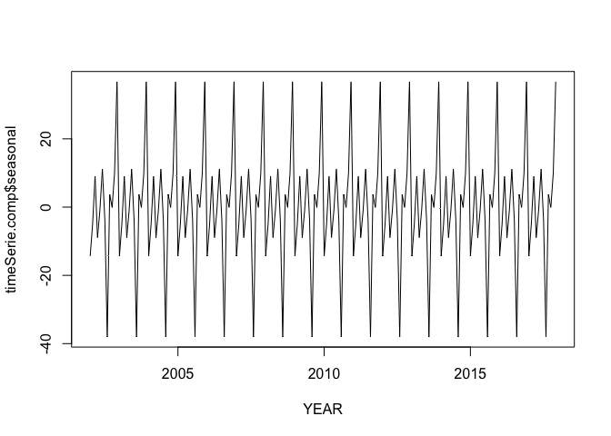

Esta es la componente de estacionalidad de la serie temporal. Al estar los datos recogídos periódicamente mes a mes es más fácil observar estas variaciones estacionales. Estas variaciones son fuerzas rítmicas que operan de manera regular en un periodo de menos de un año.

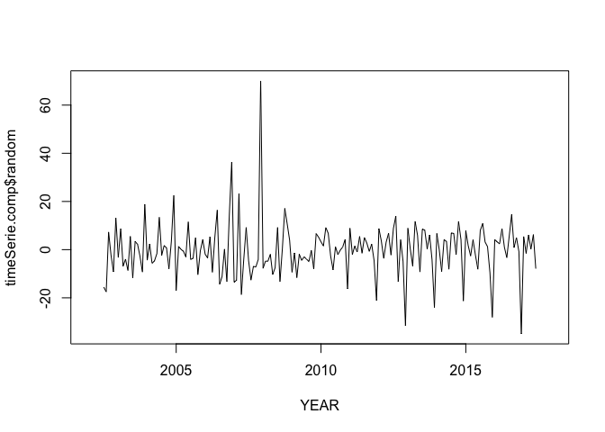

Esta es la componente aleatoria de la serie temporal, es decir, son variaciones no regulares y que tampoco responden a la estacionalidad. Estas variaciones son imprevisibles.  
Ahora podemos realizar un ajuste estacional, ya que se ha estimado el componente estacional. Este ajuste se realiza simplemente restando el componente estacional a serie temporal original.

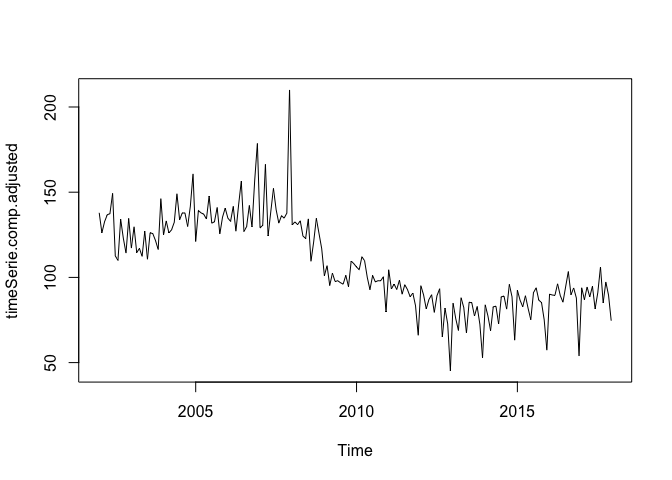

```r
timeSerie.comp.adjusted <- timeSerie.ts - timeSerie.comp$seasonal
plot.ts(timeSerie.comp.adjusted)
```

La serie temporal ajustada muestra ahora el componente tendencia y el componente aleatorio.

# Predicción de producción

Podemos descomponer la serie temporal en componente estacional, componente tendencia y componente cíclico utilizando la función *stl* para ello.

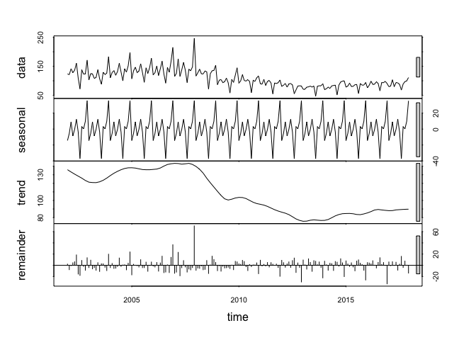

```r
decomp <- stl(timeSerie.ts, s.window = "periodic")
plot(decomp)
```

Esta descomposición es similar a la que hicimos anteriormente, pero nos añade el componente remainder. El remainder indica los residuos que se producen al ajustar la estacionalidad más la tendencia.  
Para confirmar que la serie temporal se trata de una serie estacional podemos mostrar una gráfica con las subseries por cada mes.

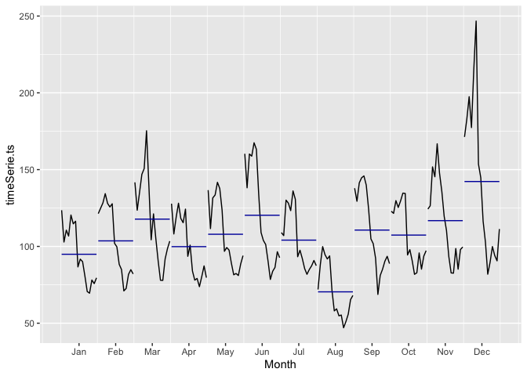

En la gráfica vemos como cada mes se mueve más o menos en la misma franja, salvo en el mes de Diciembre en el que hay más diferencia de valores. Podemos realizar las predicciones utilizando la librería forecast.

## Average Method

Este método consiste básicamente en utilizar la media para la predicción.

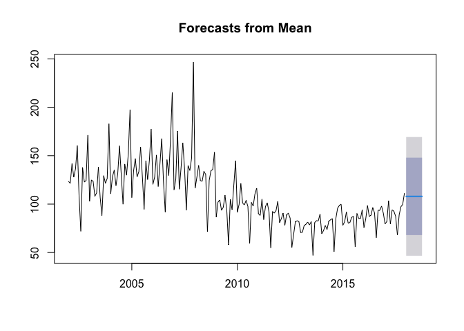

```r
forecasting.average <- meanf(timeSerie.ts, 10)
plot(forecasting.average)
```

En la gráfica podemos observar que hay una línea resaltada que es la predicción. También nos proprociona un intervalo de incertidumbre, el intervalo de color morado indica que con un 80% de probabilidad el valor se encontrará en ese intervalo. El intervalo gris indica lo mismo pero con un 95% de probabilidad.

## Naïve method

Este método utiliza los valores del último período como predicción, no lo ajusta ni trata de establecer factores casuales.

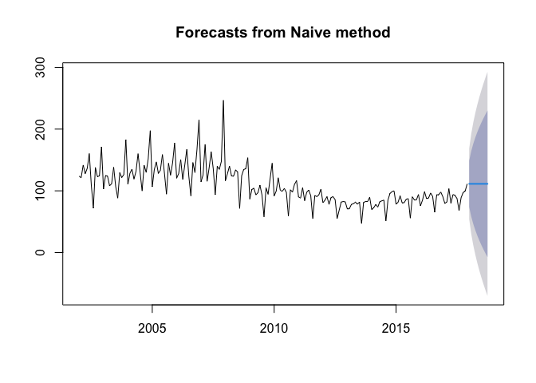

```r
forecasting.naives <- naive(timeSerie.ts, 10)
plot(forecasting.naives)
```

## Seasonal Naïve method

Esta variación del método Naïve replica lo sucedido en el último periodo que se le indique.

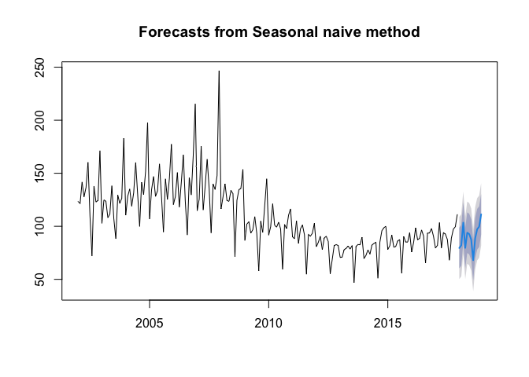

```r
forecasting.snaives <- snaive(timeSerie.ts, 12)
plot(forecasting.snaives)
```

Como se observa en la gráfica este método repite exactamente los datos del último año y los utiliza de predicción. Se ha realizado una predicción para los próximos 12 meses, se observa en la gráfica como par ala predicción se utiliza el conocimiente de toda la serie.

## Drift method

Este método hace previsiones iguales al último valor más el cambio medio, que se establece como la cantidad de cambio en el tiempo.

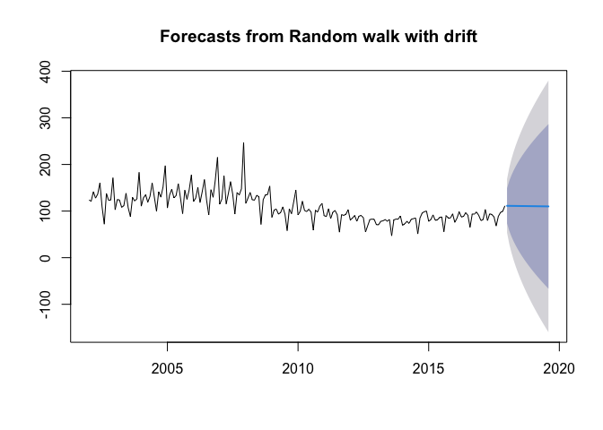

```r
forecasting.drift <- rwf(timeSerie.ts, 20, drift = TRUE)
plot(forecasting.drift)
```

La gráfica parece similar a la del método Naïve, pero en realidad se puede intuir que la línea de la predicción tiene una ligera pendiente negativa.

## Predicción utilizando Exponential Smoothing

El suavizado exponencial otorga ponderaciones a los valores de las variables, de manera que a los observaciones más recientes tienen mayor peso.  
Podemos ajustar un modelo de suavizado exponencial simple utilizando la función *HoltWinters*.

```r
timeSerie.holtWin <- HoltWinters(timeSerie.ts, beta = FALSE)
timeSerie.holtWin
```

```
## Holt-Winters exponential smoothing without trend and with additive seasonal component.
##
## Call:
## HoltWinters(x = timeSerie.ts, beta = FALSE)
##
## Smoothing parameters:
##  alpha: 0.2225627
##  beta : FALSE
##  gamma: 0.6612119
##
## Coefficients:
##            [,1]
## a   100.0039618
## s1  -14.5671604
## s2  -10.1960132
## s3    6.3646608
## s4  -12.0671659
## s5   -2.8448182
## s6   -1.4195525
## s7   -5.3535413
## s8  -28.9296504
## s9   -4.6187756
## s10   0.1362675
## s11   2.0543236
## s12   7.2070268
```

Al tratarse de una serie estacional se ajusta un coeficiente para cada estación. Podemos visualizar gráficamente el modelo HoltWinters.

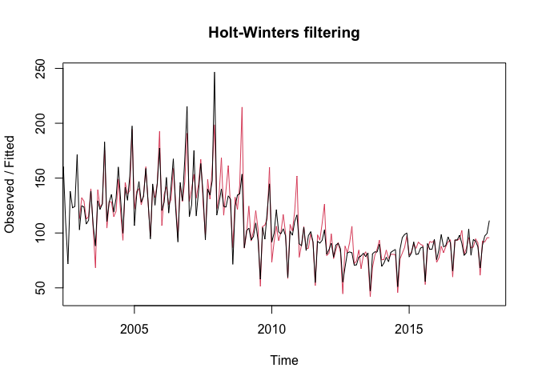

En negro se ve la serie original y en rojo se muestra la predicción que el modelo HoltWinter da teniendo encuenta los valores anteriores de la serie.  
Podemos utilizar el modelo HoltWinter ajsutado para realizar predicciones utilizando la librería *forecast*.

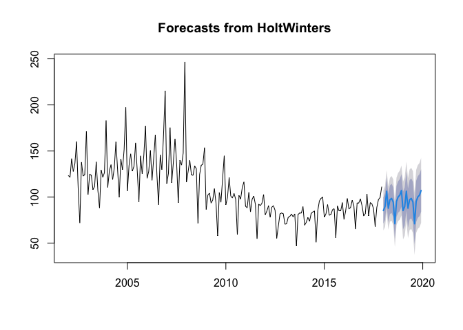

```r
timeSerie.pred.forecast <- forecast:::forecast(timeSerie.holtWin, h=24)
forecast:::plot.forecast(timeSerie.pred.forecast)
```

En la gráfica se puede observar cómo la predición realizada para los próximos 2 años tiene una forma que encaja perfectamente en la serie temporal original.

## Forecast Errors

Los errores del pronóstico se almacenan en el elemento *residuals*. Para visualizar correctamente estos errores se utiliza un correlograma que se calcula con la función *acf*, que calcula y muestra la estimación de autocovarianza o función de autocorrelación.

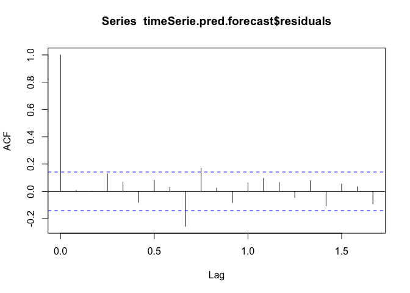

```r
acf(timeSerie.pred.forecast$residuals,na.action = na.pass, lag.max = 20)
```

Hay varios valores de Lag en los que la barra vertical supera la línea de puntos, que son los límites de significación. Esto nos da evidencias de que puede existir correlación entre los errores del pronóstico.  
Para probar si existe evidencia significativa de correlaciones distintas de cero , se puede realizar una prueba de Ljung-Box. Esto se puede hacer en R usando la función Box.test.

```r
Box.test(timeSerie.pred.forecast$residuals, lag=1.5, type="Ljung-Box")
```

```
##
##  Box-Ljung test
##
## data:  timeSerie.pred.forecast$residuals
## X-squared = 0.00601, df = 1.5, p-value = 0.9861
```

## Holt’s linear trend method

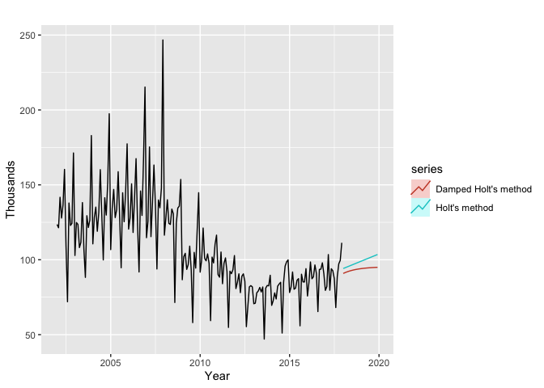

```r
ts.p1.holt <- holt(timeSerie.ts, h=24)
ts.p2.holt <- holt(timeSerie.ts, damped=TRUE, phi = 0.9, h=24)
autoplot(timeSerie.ts, xlab = "Year", ylab = "Thousands") +
  autolayer(ts.p1.holt, series="Holt's method", PI=FALSE) +
  autolayer(ts.p2.holt, series="Damped Holt's method", PI=FALSE)
```

En la gráfica que se muestra arriba podemos ver dos tipos de predicciones. Ambas predicciones se basan en el método de suavizado exponencial, el método *Damped Holt’s method* utiliza un parámetro para amortiguar la tendencia. Esto lo que hace es aplanar la tendencia a lo largo del tiempo, en lugar de ser lineal.

## Modelos ARIMA

El nombre de ARIMA viene de Autoregressive Integrated Moving Average. Para poder ajustar un modelo ARIMA hay que comprobar si la serie es estacionara, para ello se utiliza la función adf.test.

```
##
##  Augmented Dickey-Fuller Test
##
## data:  timeSerie.ts
## Dickey-Fuller = -2.066, Lag order = 5, p-value = 0.5485
## alternative hypothesis: stationary
```

En el test hemos obtenido un p-value grande, por lo que no hay evidencia de que la serie sea estacionaria. Al no ser la serie estacionaria no se puede ajustar ningún modelo ARIMA, antes hay que aplicarle diferenciación hasta transformarla en estacionaria.

```r
timeSerie.ts.diff <- diff(timeSerie.ts)
adf.test(timeSerie.ts.diff, alternative = "stationary")
```

```
##
##  Augmented Dickey-Fuller Test
##
## data:  timeSerie.ts.diff
## Dickey-Fuller = -11.098, Lag order = 5, p-value = 0.01
## alternative hypothesis: stationary
```

Una vez que se ha aplicado la diferenciación se obtiene una serie temporal estacionaria, por lo que ya se puede ajustar con un modelo ARIMA.

```r
arima.fit <- auto.arima(timeSerie.ts.diff, seasonal = FALSE)
arima.fit
```

```
## Series: timeSerie.ts.diff
## ARIMA(2,0,2) with zero mean
##
## Coefficients:
##           ar1      ar2      ma1      ma2
##       -0.7033  -0.2660  -0.1145  -0.6047
## s.e.   0.1017   0.0784   0.0859   0.0779
##
## sigma^2 estimated as 438.5:  log likelihood=-850.82
## AIC=1711.64   AICc=1711.97   BIC=1727.9
```

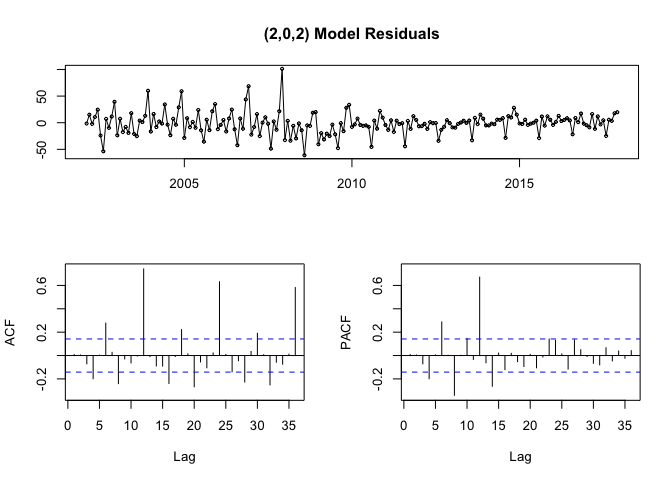

Se puede observar que en las gráficas ACF y PACF se repite el patrón hasta una valor Lag=6. Esto quiere decir que p o q (parámetros del modelo ARIMA) deben tener un valor de 6. Así que a continuación construimos dos modelos con p=6 y q=6 y comparamos el residuo de ambos modelos.

```r
fit1 <- arima(timeSerie.ts.diff, order=c(2,0,6))
fit1
```

```
##
## Call:
## arima(x = timeSerie.ts.diff, order = c(2, 0, 6))
##
## Coefficients:
##           ar1     ar2      ma1      ma2     ma3      ma4      ma5     ma6
##       -0.7247  0.0620  -0.0690  -0.9099  0.2342  -0.2361  -0.1245  0.4947
## s.e.   0.1955  0.1917   0.1841   0.1163  0.2355   0.1110   0.1036  0.0782
##       intercept
##         -0.2193
## s.e.     0.3200
##
## sigma^2 estimated as 356.7:  log likelihood = -834.01,  aic = 1688.02
```

```r
fit2 <- arima(timeSerie.ts.diff, order=c(6,0,2))
fit2
```

```
##
## Call:
## arima(x = timeSerie.ts.diff, order = c(6, 0, 2))
##
## Coefficients:
##          ar1      ar2     ar3      ar4     ar5     ar6      ma1     ma2
##       0.1048  -0.1555  0.1268  -0.2683  0.0488  0.2934  -0.9263  0.0640
## s.e.  0.1956   0.1109  0.1169   0.0909  0.1171  0.0933   0.1879  0.1172
##       intercept
##         -0.2075
## s.e.     0.2284
##
## sigma^2 estimated as 361.4:  log likelihood = -834.75,  aic = 1689.51
```

Para comparar los modelos utilizaré el Akaike Information Criteria (AIC), esta es una medida ampliamente usada que cuantifica la bondad del ajuste y la simplicidad del modelo.

```r
AIC(fit1); AIC(fit2)
```

```
## [1] 1688.024
```

```
## [1] 1689.509
```

El modelo (2,0,6) tiene un mejor AIC, además el valor obtenido es mejor que en el modelo de AUTOARIMA. Así que el modelo (2,0,6) será utilizado para las predicciones. La predicción es la siguiente.

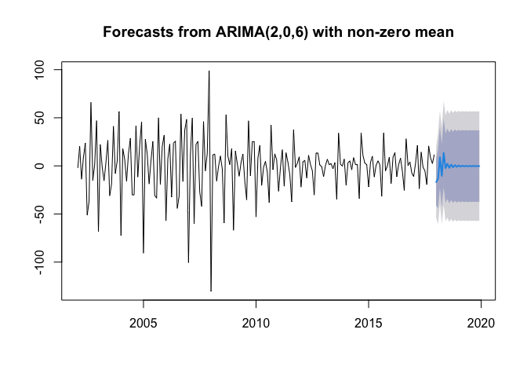

# Análisis de serie temporal de Tasa de Actividad en España.

Ahora se va a analizar la serie temporal de la tasa de actividad de España desde 2002 hasta la actualidad, que ha sido descargada del INE.

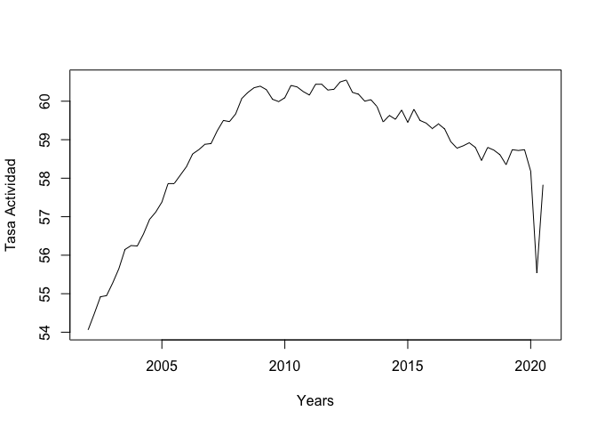

```r
actividad <- read.csv("Actividad.csv", row.names = NULL, sep = ";")
actividad <- actividad[order(nrow(actividad):1),]
actividad.ts <- ts(actividad$Datos, start = c(2002, 1), frequency = 4)
plot.ts(actividad.ts, ylab = "Tasa Actividad", xlab = "Years")
```

La tasa de actividad es un índice que mide el nivel de empleo de un país, y es una variable muy importante en el crecimiento económico a largo plazo. La fórmula que se utiliza para calcular la tasa de actividad es la siguiente: $TasaActividad = \frac{PoblacionActiva}{PoblacionMayor16}*100$  
En la gráfica de la serie temporal se puede observar como hay un crecimiento constante desde 2002 (que es donde comienzan los datos utilizados) hasta un poco antes de 2010, a partir de 2010 la serie se vuelve menos constante y se intuye un decrecimiento que se va acentuándo con el paso de los años. Incluso se puede observar la gran incidencia de la pandemia del COVID19, ya que en 2020 se produce un gran pico hacia abajo.

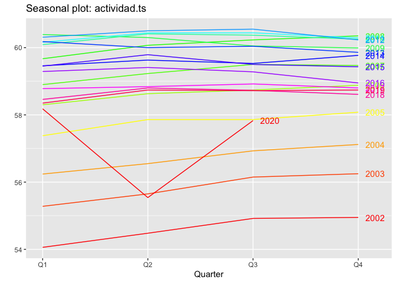

```r
ggseasonplot(actividad.ts, col=rainbow(18), year.labels=TRUE)
```

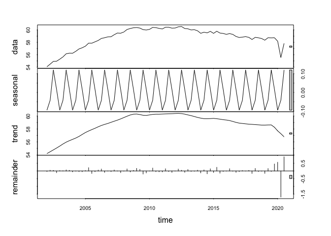

```r
decom_ta <- stl(actividad.ts, s.window = "periodic")
plot(decom_ta)
```

En este análisis hemos obtenido un resultado interesante. En la gráfica remainde, que muestra los residuos del ajuste de la estacionalidad y la tendencia, se observa cómo los residuos son prácticamente despreciables a lo largo del tiempo. Sin embargo, en 2020 se disparan (justo en la época del confinamiento), lo que nos indica que ha sucedido un evento anómalo.  
En el componente de tendencia se puede observar como desde aproximadamente 2012 la tasa de actividad baja de manera acelerada, es decir, disminuye cada vez más con el paso de los años.  
Otra buena forma de entender la serie temporal es mostrar gráficamente las subseries de cada trimestre.

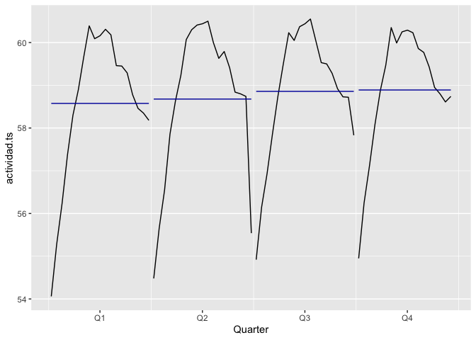

## Predicción utilizando Suavizado Exponencial

En esta sección se utilizará el método de suavizado exponencial para realizar predicciones sobre la serie temporal. Para ello primero debemos ajustar un modelo **HoltWinters**.

```
## Holt-Winters exponential smoothing without trend and with additive seasonal component.
##
## Call:
## HoltWinters(x = actividad.ts, beta = FALSE)
##
## Smoothing parameters:
##  alpha: 0.7314132
##  beta : FALSE
##  gamma: 0.03450507
##
## Coefficients:
##            [,1]
## a  57.297892731
## s1 -0.063950662
## s2 -0.066088525
## s3 -0.008088781
## s4  0.174252705
```

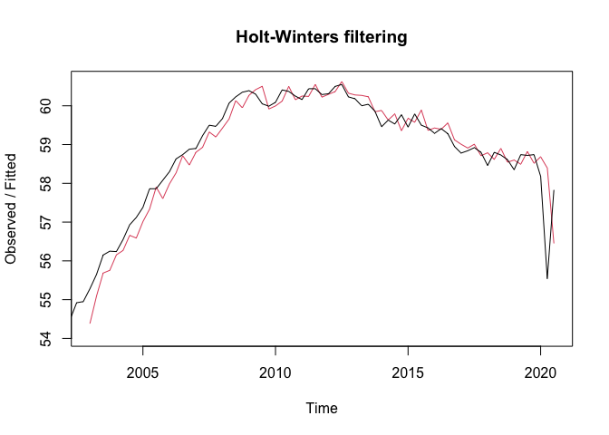

En la gráfica se observa en negro la serie temporal y en rojo el ajuste que realiza el modelo Holt Winters. El ajuste ha conseguido suavizar la caída en picado de 2020, pero el resto de la serie se producen picos más abruptos que en la serie original.  
El modelo Holt Winters se puede utilizar para realizar predicciones, utilizando la librería *forecast*.

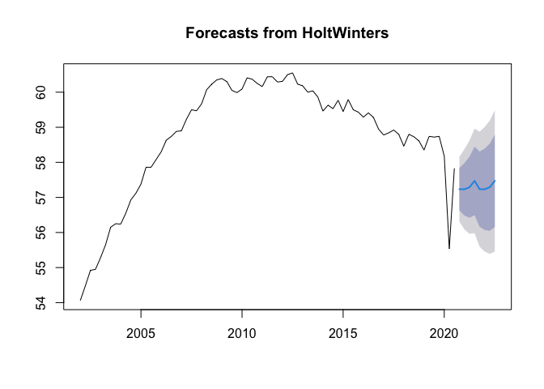

```r
actividad.ts.holtWin.forecast <- forecast:::forecast(actividad.ts.holtWin, h=8)
forecast:::plot.forecast(actividad.ts.holtWin.forecast)
```

La predicción se ha realizado para los próximos dos años. Como se observa, la predicción es similar a la serie original, aunque el intervalo de incertidumbre es sensiblemente amplio.

## Forecast Errors

Una de las ventajas de la predicción con forecast es almacena los errores en el atributo *residuals*. Estos errores se pueden visualizar.

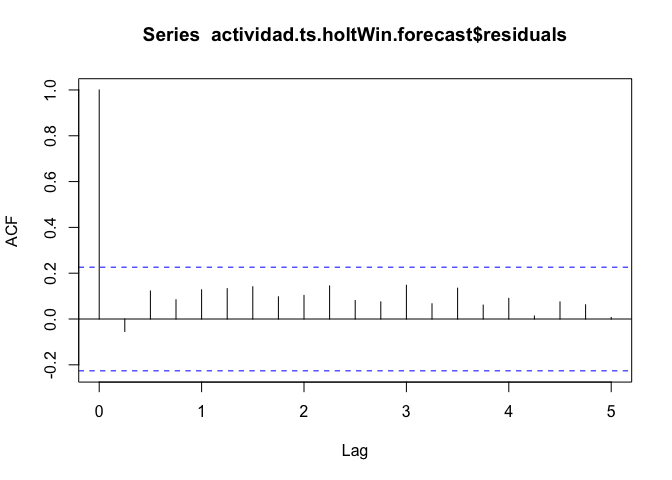

No hay ninguna barra vertical que supere los límites de significado, que es buen indicador de que no hay correlación entre los errores de pronóstico. Para comprobar la correlación se puede realizar un test de Ljung-Box.

```r
Box.test(actividad.ts.holtWin.forecast$residuals, lag=5, type="Ljung-Box")
```

```
##
##  Box-Ljung test
##
## data:  actividad.ts.holtWin.forecast$residuals
## X-squared = 4.5226, df = 5, p-value = 0.4769
```

## Modelos ARIMA

Se va a intentar ajustar un modelo ARIMA para esta serie temporal. En primer lugar hay que comprobar si la serie es estacionaria o no, para ello se utiliza la función adf.test.

```r
adf.test(actividad.ts, alternative = "stationary")
```

```
##
##  Augmented Dickey-Fuller Test
##
## data:  actividad.ts
## Dickey-Fuller = -2.1983, Lag order = 4, p-value = 0.4946
## alternative hypothesis: stationary
```

El test nos indica que la serie no es estacionaria, así que hay que diferenciar la serie temporal.

```r
diff.ts <- diff(actividad.ts)
adf.test(diff.ts, alternative = "stationary")
```

```
##
##  Augmented Dickey-Fuller Test
##
## data:  diff.ts
## Dickey-Fuller = -3.4721, Lag order = 4, p-value = 0.05078
## alternative hypothesis: stationary
```

Con la serie diferenciada obtenemos un p-value de 0.05, que se encuentra justo en el umbral para aceptar la hipótesis alternativa. Ahora ajustamos un modelo AUTOARIMA.

```r
arima.auto <- auto.arima(diff.ts, seasonal = FALSE)
arima.auto
```

```
## Series: diff.ts
## ARIMA(0,1,0)
##
## sigma^2 estimated as 0.4738:  log likelihood=-76.32
## AIC=154.64   AICc=154.69   BIC=156.93
```

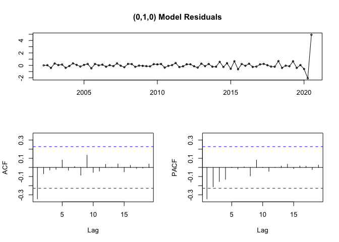

El modelo que se ha ajustado es (0,1,0), pero en las gráfias de ACF y PACF en el valor de Lag=1 el valor es el mismo. Esto indica que podemos ajustar un modelo donde p o q sean 1. Se va a ajustar un modelo ARIMA(1,1,1), para tener en cuenta al menos un valor anterior para la predicción.

```r
arima.fit2 <- arima(diff.ts, order = c(1,1,1))

AIC(arima.fit2)
```

```
## [1] 91.27282
```

El AIC obtenido es mejor que el obtenido en el modelo AUTOARIMA. Utilizamos este modelo para la predicción.

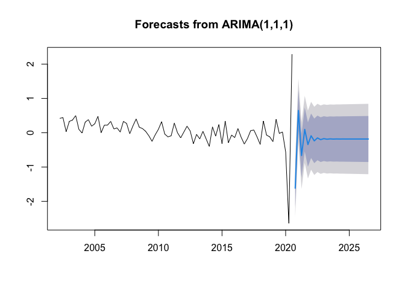

Esta es la predicción obtenida, se puede observar como el gran pico en 2020 influencia en gran medida la predicción que se ha realizado. Esto se debe al valor tan bajo que se le ha dado a q, que indica el número de valores anteriores de la serie que se utilizan.